# Descriptives

# Data inspection

This markdown provides descriptive data about the datasets to explore them further and ensure there were no substantial errors in the data wrangling process.

We will first have a look at the data itself. The dataset has 12672 participants and 32400 individual responses. We will analyse the variables of interest (life satisfaction and social media use). The participants had a mean age of 12.59 (SD = 1.68), the ages ranged from 10 to 15. We note that while the Understanding Society website states that adolescents are 11-15, the survey also includes 10 year olds. There were 6270 girls and 6402 boys.

### Number of participants in each wave

```r
table_1 <- table(data_long$year)
table_1 <- as.data.frame(table_1)
knitr::kable(table_1, col.names = c("Wave", "Number of Individuals"), caption = "Number if Individuals per Wave")
```

Number if Individuals per Wave

| Wave | Number of Individuals |
| --- | --- |
| 2009 | 4899 |
| 2010 | 5018 |
| 2011 | 4426 |
| 2012 | 4043 |
| 2013 | 3655 |
| 2014 | 3460 |
| 2015 | 3629 |
| 2016 | 3270 |

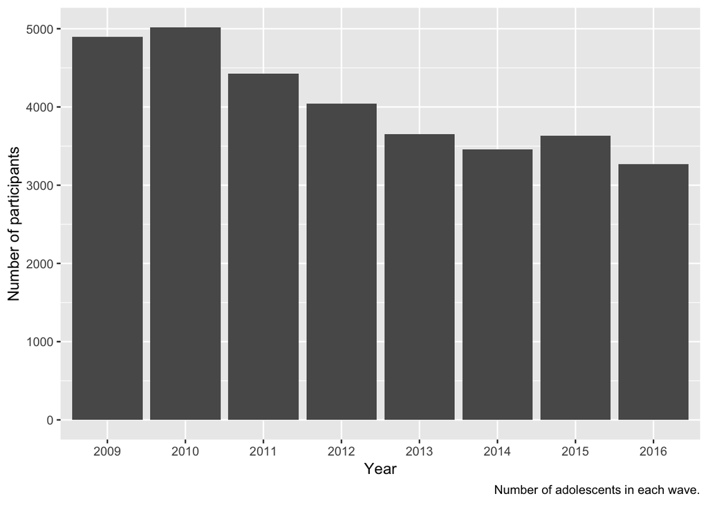

```r
ggplot(data = table_1) +
  geom_bar(aes(x = Var1, y = Freq), stat = "identity") +
  labs(x = "Year", y = "Number of participants", caption = "Number of adolescents in each wave.")
```

### Number of individuals answering each question

Not every question was asked in every wave, we therefore need to examine the number of participants who answered each question:

```r
table_2 <- colSums(!is.na(data_long))
table_2 <- table_2[2:length(table_2)]
knitr::kable(table_2, caption = "Number if Individuals per Question")
```

Number if Individuals per Question

|  | x |
| --- | --- |
| y_age | 32400 |
| y_male | 32400 |
| pn1sex | 31733 |
| pn2sex | 20897 |
| pns1sex | 31929 |
| pns2sex | 23944 |
| mnpid | 30850 |
| socweb | 31986 |
| y_famsup | 29685 |
| netcht | 23541 |
| tvvidhrs | 32227 |
| comp | 16438 |
| pchw | 15627 |
| cintnt | 15579 |
| cpgs | 15617 |
| consol | 16434 |
| constm | 15160 |
| mobu | 16430 |
| hsw | 32146 |
| hap | 32068 |
| hfm | 32123 |
| hfr | 32142 |
| hsc | 32110 |
| hlf | 32061 |
| sdqa | 16393 |
| sdqb | 16331 |
| sdqc | 16342 |
| sdqd | 16371 |
| sdqe | 16339 |
| sdqf | 16354 |

[output cut: 57 more lines]

It is easier to examine the participants per question per year, and only those variables that are of interest in our study. We note that while y_famsup and m_socialwithkid was only measured every other year, we infered the yearly data in the previous data wrangling script. Furthermore, m_nonwhite is only asked once, so we also infer the subsequent answers from the answer given in the first wave.

```r
table_3 <- data_long %>%
  group_by(year) %>%
  summarise_all(funs(sum(!is.na(.)))) %>%
  select(year, lifesat, hsw, hap, hfm, hfr, hsc, hlf,
  netchtpool,y_age, y_male, y_famsup, m_employed,m_depressed,
  m_nonwhite, m_nkids, m_socialwithkid)
knitr::kable(table_3, caption = "Number if Individuals per Question per Year")
```

Number if Individuals per Question per Year

| year | lifesat | hsw | hap | hfm | hfr | hsc | hlf | netchtpool | y_age | y_male | y_famsup | m_employed | m_depressed | m_nonwhite | m_nkids | m_socialwithkid |
| --- | --- | --- | --- | --- | --- | --- | --- | --- | --- | --- | --- | --- | --- | --- | --- | --- |
| 2009 | 4881 | 4870 | 4864 | 4874 | 4876 | 4870 | 4859 | 4630 | 4899 | 4899 | 4884 | 4457 | 4390 | 4428 | 4457 | 4375 |
| 2010 | 5000 | 4979 | 4971 | 4979 | 4972 | 4978 | 4974 | 4995 | 5018 | 5018 | 4248 | 4594 | 4358 | 3607 | 4658 | 3900 |
| 2011 | 4402 | 4389 | 4381 | 4391 | 4386 | 4380 | 4380 | 4409 | 4426 | 4426 | 4399 | 4050 | 3743 | 3165 | 4127 | 4031 |
| 2012 | 4036 | 4023 | 4015 | 4016 | 4019 | 4012 | 4014 | 4024 | 4043 | 4043 | 3636 | 3692 | 3492 | 2932 | 3788 | 3414 |
| 2013 | 3626 | 3615 | 3594 | 3604 | 3611 | 3611 | 3592 | 3618 | 3655 | 3655 | 3528 | 3380 | 3156 | 2673 | 3447 | 3382 |
| 2014 | 3452 | 3436 | 3428 | 3423 | 3435 | 3423 | 3408 | 3378 | 3460 | 3460 | 3040 | 3169 | 3074 | 2481 | 3210 | 2888 |
| 2015 | 3611 | 3595 | 3582 | 3591 | 3601 | 3595 | 3591 | 3587 | 3629 | 3629 | 3605 | 3362 | 3228 | 2711 | 3388 | 3338 |
| 2016 | 3262 | 3239 | 3233 | 3245 | 3242 | 3241 | 3243 | 3245 | 3270 | 3270 | 2345 | 3032 | 2903 | 2423 | 3038 | 2214 |

### Question means across years

We can also look at the question means across years to see whether there are any major changes over time.

```r
table_4 <- data_long %>%
  group_by(year) %>%
  summarise_all(funs(mean(., na.rm = TRUE))) %>%
  mutate_at(vars(-year), funs(round(.,2))) %>%
  select(year, lifesat, hsw, hap, hfm, hfr, hsc, hlf,
  netchtpool,y_age, y_famsup, m_employed,m_depressed,
  m_nonwhite, m_nkids, m_socialwithkid)
knitr::kable(table_4, caption = "Mean of Question by Year")
```

Mean of Question by Year

| year | lifesat | hsw | hap | hfm | hfr | hsc | hlf | netchtpool | y_age | y_famsup | m_employed | m_depressed | m_nonwhite | m_nkids | m_socialwithkid |
| --- | --- | --- | --- | --- | --- | --- | --- | --- | --- | --- | --- | --- | --- | --- | --- |
| 2009 | 5.85 | 5.36 | 5.40 | 6.38 | 6.39 | 5.65 | 5.90 | 2.07 | 12.5 | 2.78 | 0.65 | 1.98 | 0.74 | 2.19 | 3.37 |
| 2010 | 5.86 | 5.47 | 5.33 | 6.39 | 6.37 | 5.66 | 5.94 | 2.15 | 12.5 | 2.80 | 0.66 | 2.10 | 0.76 | 2.18 | 3.49 |
| 2011 | 5.89 | 5.51 | 5.32 | 6.42 | 6.39 | 5.75 | 5.94 | 2.10 | 12.5 | 2.79 | 0.69 | 2.07 | 0.75 | 2.17 | 3.53 |
| 2012 | 5.85 | 5.54 | 5.32 | 6.37 | 6.26 | 5.69 | 5.91 | 2.03 | 12.6 | 2.80 | 0.70 | 2.08 | 0.74 | 2.13 | 3.58 |
| 2013 | 5.85 | 5.51 | 5.30 | 6.37 | 6.29 | 5.75 | 5.87 | 2.08 | 12.6 | 2.78 | 0.71 | 2.07 | 0.74 | 2.14 | 3.50 |
| 2014 | 5.81 | 5.48 | 5.31 | 6.38 | 6.22 | 5.61 | 5.86 | 2.10 | 12.6 | 2.80 | 0.70 | 1.96 | 0.72 | 2.13 | 3.57 |
| 2015 | 5.85 | 5.53 | 5.41 | 6.39 | 6.27 | 5.67 | 5.84 | 2.18 | 12.5 | 2.79 | 0.69 | 2.08 | 0.65 | 2.15 | 3.50 |
| 2016 | 5.77 | 5.42 | 5.36 | 6.39 | 6.17 | 5.51 | 5.80 | 2.33 | 12.5 | 2.80 | 0.70 | 2.08 | 0.65 | 2.10 | 3.55 |

We can look at lifesatisfaction and social media use across years as well.

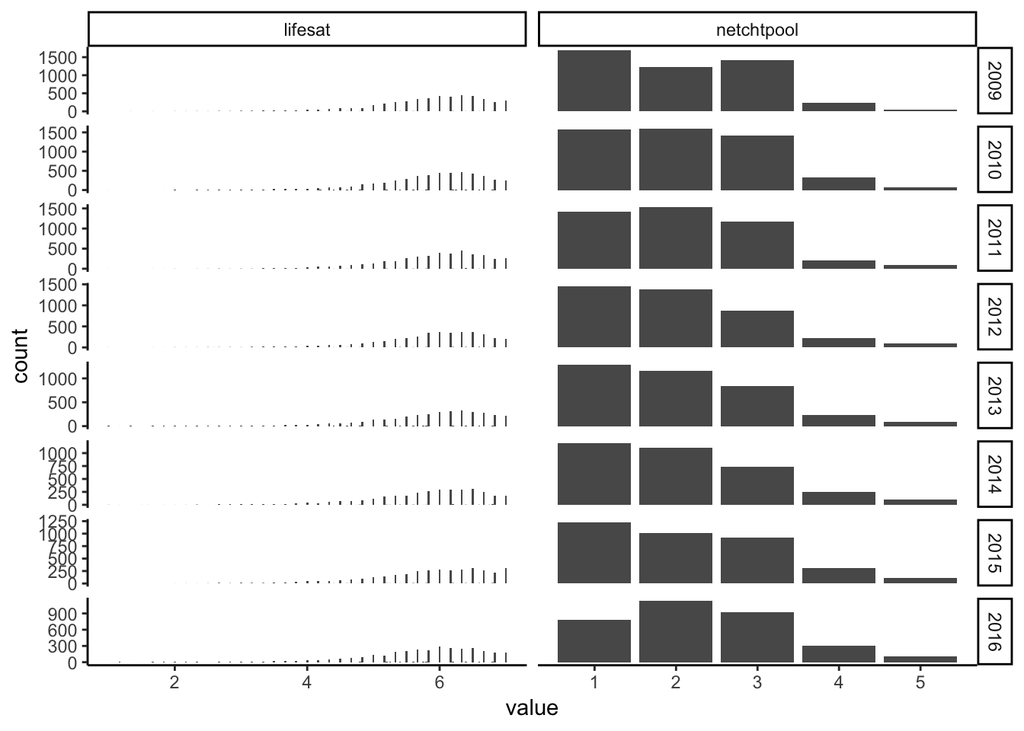

```r
data_long %>%
  select("lifesat", "netchtpool", "pidp", "year") %>%
  gather(var, value, -c("pidp", "year")) %>%
  ggplot(aes(x = value)) +
  geom_bar() +
  facet_grid(year ~ var, scales = 'free') +
  theme_classic()
```

### Variable correlations

We also look at the correlations between variables, to get an overview of the data and to check for any mistakes in recoding. First, we examine the correlation between the different domains of life satisfaction and our social media use measure. The different satisfaction measures are hap (appearance), hfm (family), hfr (friends), hlf (life), hsc (school), hsw (schoolwork), lifesat (mean). We also examine netchtpool (social media use):

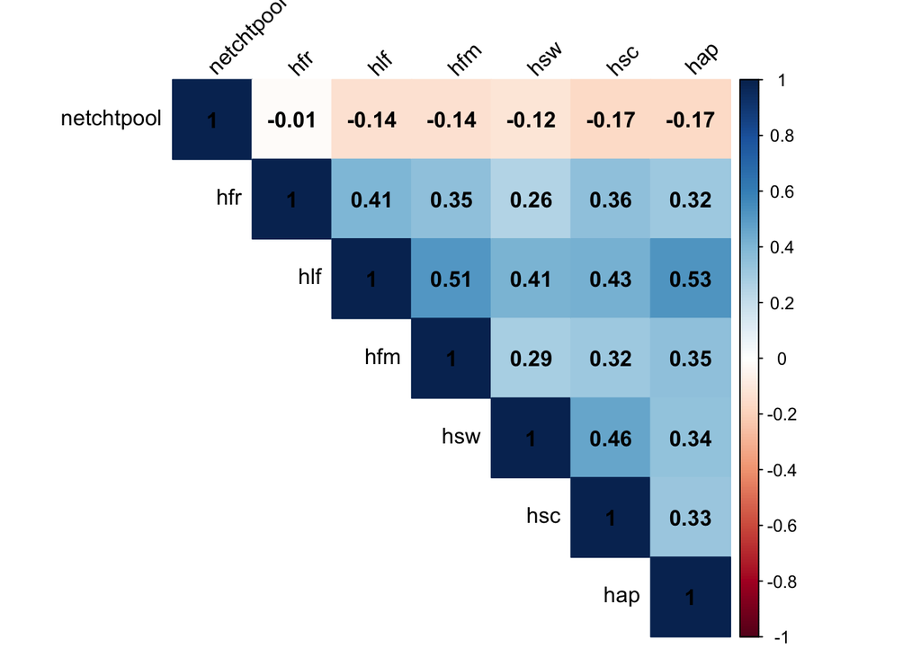

```r
vars_data <- subset(data_long, select = c(variables$vars_lfsat, "netchtpool"))
correlate <- psych::corr.test(vars_data)
corrplot(correlate$r, type = "upper", method = "color", addCoef.col = "black",
         tl.col = "black", tl.srt = 45, order = "AOE")
```

Because of our focus on differences in gender, we also have a look just for girls:

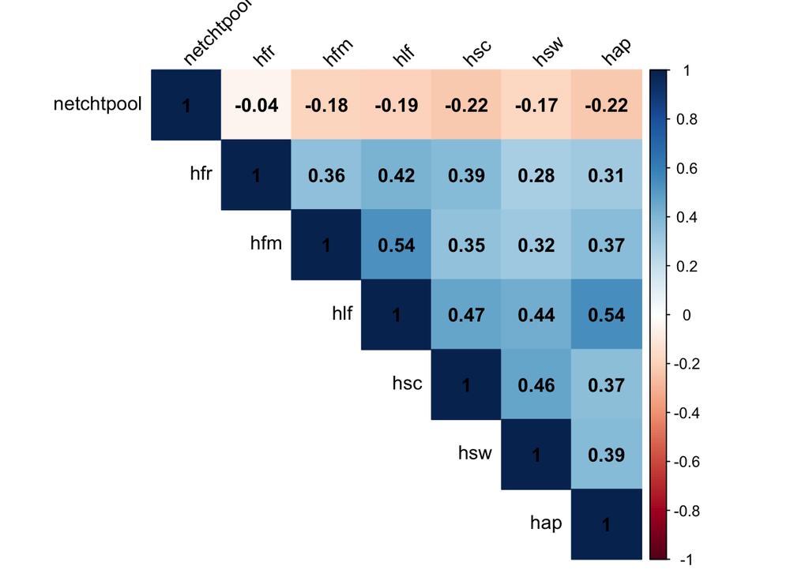

```r
vars_data <- subset(data_long, select = c(variables$vars_lfsat, "netchtpool", "y_male"))
vars_data_g <- vars_data %>%
  filter(y_male == 0) %>%
  select(-y_male)
correlate <- psych::corr.test(vars_data_g)
corrplot(correlate$r, type = "upper", method = "color", addCoef.col = "black",
         tl.col = "black", tl.srt = 45, order = "AOE")
```

And also boys:

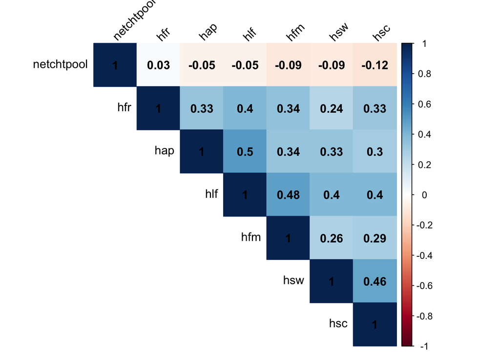

```r
vars_data_b <- vars_data %>%
  filter(y_male == 1) %>%
  select(-y_male)
correlate <- psych::corr.test(vars_data_b)
corrplot(correlate$r, type = "upper", method = "color", addCoef.col = "black",
         tl.col = "black", tl.srt = 45, order = "AOE")
```

### Trends over Time

We also examine trends in the measures over time. For this we use a summary function shown below:

```r
summary_se <- function(data=NULL, measurevar, groupvars=NULL, na.rm=FALSE,
                      conf.interval=.95, .drop=TRUE) {

    # New version of length which can handle NA's: if na.rm==T, don't count them
    length2 <- function (x, na.rm=FALSE) {
        if (na.rm) sum(!is.na(x))
        else       length(x)
    }

    # This does the summary. For each group's data frame, return a vector with
    # N, mean, and sd
    datac <- ddply(data, groupvars, .drop=.drop,
      .fun = function(xx, col) {
        c(N    = length2(xx[[col]], na.rm=na.rm),
          mean = mean   (xx[[col]], na.rm=na.rm),
          sd   = sd     (xx[[col]], na.rm=na.rm)
        )
      },
      measurevar
    )

    # # Rename the "mean" column
    # datac <- plyr::rename(datac, c("mean" = measurevar))

    datac$se <- datac$sd / sqrt(datac$N)  # Calculate standard error of the mean

    # Confidence interval multiplier for standard error
    # Calculate t-statistic for confidence interval:
    # e.g., if conf.interval is .95, use .975 (above/below), and use df=N-1
    ciMult <- qt(conf.interval/2 + .5, datac$N-1)
    datac$ci <- datac$se * ciMult

    return(datac)
}
```

```r
calc_means <- function(measurevar, data, groupvars, na.rm){
  # function that calculates data such as means from data set

  tmp <- summary_se(data, measurevar, groupvars, na.rm)
  tmp$variable <- measurevar
  return(tmp)
}
```

We first examine the trends in life satisfaction measures and social media use over the study waves.

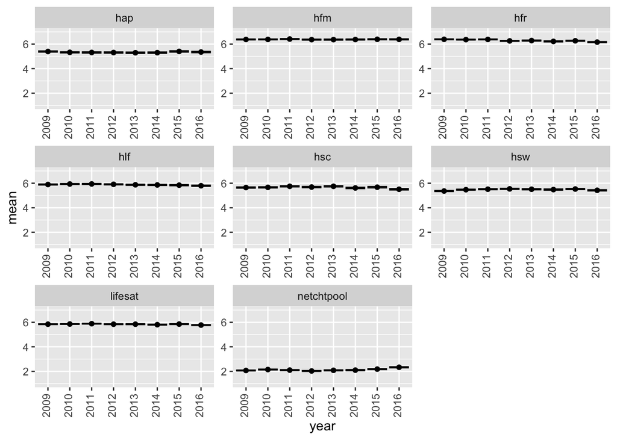

```r
vars_lifesat <- c("netchtpool", variables$vars_lfsat, "lifesat")  # select vars
means_lifesat <- lapply(vars_lifesat, calc_means, data = data_long, groupvars = "year", na.rm = TRUE) %>%
  ldply()

p_means <- ggplot(means_lifesat,
                  aes(x = year, y = mean, ymin = mean - ci, ymax = mean + ci)) +
  geom_errorbar() +
  geom_point() +
  scale_y_continuous(limits = c(1,7)) +
  theme(axis.text.x = element_text(angle = 90, hjust = 1, vjust = 0.3)) +
  facet_wrap( ~ variable, scales = "free")
plot(p_means)
```

We can take a look at the gender differences in these trends as well:

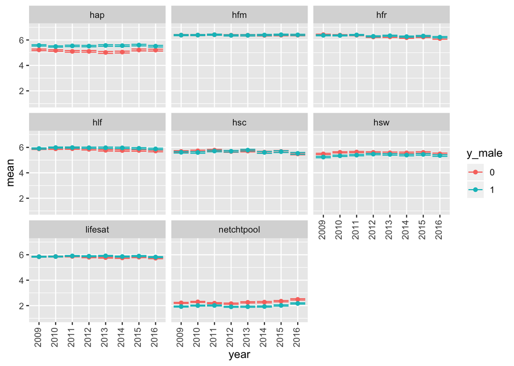

```r
means_lifesat_gender <- lapply(vars_lifesat, calc_means, data = data_long, groupvars = c("year", "y_male"), na.rm = TRUE) %>%
  ldply()
p_means_gender <- ggplot(means_lifesat_gender,
                  aes(x = year, y = mean, ymin = mean - ci, ymax = mean + ci, colour = y_male)) +
  geom_errorbar() +
  geom_point() +
  scale_y_continuous(limits = c(1,7)) +
  theme(axis.text.x = element_text(angle = 90, hjust = 1, vjust = 0.3)) +
  facet_wrap(~ variable)
plot(p_means_gender)
```

### CFA of life satisfaction

We can examine a CFA of life satisfaction as a measure, to help us determine the nature of the measurement.

```r
model <- '
lifsat =~ hsw + hap + hfm + hfr + hsc + hlf
'
fit_lifsat <- cfa(model, data_long %>% filter(year == 2009), estimator = "MLR")
summary(fit_lifsat, std = TRUE, fit = TRUE)
```

```
## lavaan 0.6-3 ended normally after 28 iterations
##
##   Optimization method                           NLMINB
##   Number of free parameters                         12
##
##                                                   Used       Total
##   Number of observations                          4823        4899
##
##   Estimator                                         ML      Robust
##   Model Fit Test Statistic                     452.264     279.805
##   Degrees of freedom                                 9           9
##   P-value (Chi-square)                           0.000       0.000
##   Scaling correction factor                                  1.616
##     for the Yuan-Bentler correction (Mplus variant)
##
## Model test baseline model:
##
##   Minimum Function Test Statistic             6349.177    3825.391
##   Degrees of freedom                                15          15
##   P-value                                        0.000       0.000
##
## User model versus baseline model:
##
##   Comparative Fit Index (CFI)                    0.930       0.929
##   Tucker-Lewis Index (TLI)                       0.883       0.882
##
##   Robust Comparative Fit Index (CFI)                         0.931
##   Robust Tucker-Lewis Index (TLI)                            0.885
##
## Loglikelihood and Information Criteria:
##
##   Loglikelihood user model (H0)             -43827.541  -43827.541
##   Scaling correction factor                                  2.092
##     for the MLR correction
##   Loglikelihood unrestricted model (H1)     -43601.409  -43601.409
##   Scaling correction factor                                  1.888
##     for the MLR correction
##
##   Number of free parameters                         12          12
##   Akaike (AIC)                               87679.082   87679.082
```

[output cut: 26 more lines]

```
##     hap               1.145    0.053   21.527    0.000    0.809    0.561
##     hfm               0.911    0.051   17.889    0.000    0.644    0.615
##     hfr               0.680    0.041   16.609    0.000    0.480    0.508
##     hsc               1.245    0.043   28.740    0.000    0.880    0.592
##     hlf               1.258    0.058   21.862    0.000    0.889    0.752
##
## Variances:
##                    Estimate  Std.Err  z-value  P(>|z|)   Std.lv  Std.all
##    .hsw               1.203    0.039   30.567    0.000    1.203    0.707
##    .hap               1.422    0.040   35.196    0.000    1.422    0.685
##    .hfm               0.682    0.026   26.221    0.000    0.682    0.622
##    .hfr               0.664    0.026   25.581    0.000    0.664    0.742
##    .hsc               1.436    0.050   28.627    0.000    1.436    0.650
##    .hlf               0.605    0.029   20.842    0.000    0.605    0.434
##     lifsat            0.499    0.036   13.983    0.000    1.000    1.000
```

# ICC

Before we run our RI-CLPMs, we also check how much variance is due to within-person changes vs. between-person differences. We do this by calculating icc values

```r
# Life satisfaction
## hsw
model_0_hsw <- lmer(hsw ~ (1 | pidp), data_long)  # estimate null model
icc_hsw <- icc(model_0_hsw)  # get ICC

## hap
model_0_hap <- lmer(hap ~ (1 | pidp), data_long)  # estimate null model
icc_hap <- icc(model_0_hap)  # get ICC

## hfm
model_0_hfm <- lmer(hfm ~ (1 | pidp), data_long)  # estimate null model
icc_hfm <- icc(model_0_hfm)  # get ICC

## hfr
model_0_hfr <- lmer(hfr ~ (1 | pidp), data_long)  # estimate null model
icc_hfr <- icc(model_0_hfr)  # get ICC

## hsc
model_0_hsc <- lmer(hsc ~ (1 | pidp), data_long)  # estimate null model
icc_hsc <- icc(model_0_hsc)  # get ICC

## hlf
model_0_hlf <- lmer(hlf ~ (1 | pidp), data_long)  # estimate null model
icc_hlf <- icc(model_0_hlf)  # get ICC

## combine
icc_lifesat <- c(icc_hsw, icc_hap, icc_hfm, icc_hfr, icc_hsc, icc_hlf)

# Social media use
model_0_netchtpool <- lmer(netchtpool ~ (1 | pidp), data_long)  # estimate null model
icc_netchtpool <- icc(model_0_netchtpool)  # get ICC
```

We find that 27.397 - 43.434 percent of the variance in life satisfaction is due to between-person differences. As a direct result, 72.603 - 56.566 percent of the variance in life satisfaction result from within-person changes.

Next, we find that 30.242 percent of the variance in social media use is due to between-person differences. Hence, 69.758 percent of the variance in social media use result from within-person changes.

Both results show that it is highly useful to run a cross-lagged panel model with random intercepts, as considerable parts of variance might be due to between person differences and not to within-person effects.